# ml project

jenwong-hk

December 15, 2018

## Background:

In this project, we will use data from accelerometers on the belt, forearm, arm, and dumbell of 6 participants. They were asked to perform barbell lifts correctly and incorrectly in 5 different ways.

## Objective:

Use the above data to predict how well people do in the activity.

## Cross Validation:

We use K fold as cross validation method to check/choose the best accuracy model for predicting the testing data.

## Result:

We select the 2nd model to apply to the testing data and achieve 95% accuracy in the Project Quiz, therefore the 2nd model is our answer. Details are as follows:

```
## 'data.frame':    19622 obs. of  160 variables:
##  $ X                       : int  1 2 3 4 5 6 7 8 9 10 ...
##  $ user_name               : Factor w/ 6 levels "adelmo","carlitos",..: 2 2 2 2 2 2 2 2 2 2 ...
##  $ raw_timestamp_part_1    : int  1323084231 1323084231 1323084231 1323084232 1323084232 1323084232 1323084232 1323084232 1323084232 1323084232 ...
##  $ raw_timestamp_part_2    : int  788290 808298 820366 120339 196328 304277 368296 440390 484323 484434 ...
##  $ cvtd_timestamp          : Factor w/ 20 levels "02/12/2011 13:32",..: 9 9 9 9 9 9 9 9 9 9 ...
##  $ new_window              : Factor w/ 2 levels "no","yes": 1 1 1 1 1 1 1 1 1 1 ...
##  $ num_window              : int  11 11 11 12 12 12 12 12 12 12 ...
##  $ roll_belt               : num  1.41 1.41 1.42 1.48 1.48 1.45 1.42 1.42 1.43 1.45 ...
##  $ pitch_belt              : num  8.07 8.07 8.07 8.05 8.07 8.06 8.09 8.13 8.16 8.17 ...
##  $ yaw_belt                : num  -94.4 -94.4 -94.4 -94.4 -94.4 -94.4 -94.4 -94.4 -94.4 -94.4 ...
##  $ total_accel_belt        : int  3 3 3 3 3 3 3 3 3 3 ...
##  $ kurtosis_roll_belt      : Factor w/ 397 levels "","-0.016850",..: 1 1 1 1 1 1 1 1 1 1 ...
##  $ kurtosis_picth_belt     : Factor w/ 317 levels "","-0.021887",..: 1 1 1 1 1 1 1 1 1 1 ...
##  $ kurtosis_yaw_belt       : Factor w/ 2 levels "","#DIV/0!": 1 1 1 1 1 1 1 1 1 1 ...
```

[output cut: 86 more lines]

```
## 'data.frame':    19622 obs. of  62 variables:
##  $ amplitude_roll_dumbbell : num  NA NA NA NA NA NA NA NA NA NA ...
##  $ amplitude_pitch_dumbbell: num  NA NA NA NA NA NA NA NA NA NA ...
##  $ amplitude_yaw_dumbbell  : Factor w/ 3 levels "","#DIV/0!","0.00": 1 1 1 1 1 1 1 1 1 1 ...
##  $ total_accel_dumbbell    : int  37 37 37 37 37 37 37 37 37 37 ...
##  $ var_accel_dumbbell      : num  NA NA NA NA NA NA NA NA NA NA ...
##  $ avg_roll_dumbbell       : num  NA NA NA NA NA NA NA NA NA NA ...
##  $ stddev_roll_dumbbell    : num  NA NA NA NA NA NA NA NA NA NA ...
##  $ var_roll_dumbbell       : num  NA NA NA NA NA NA NA NA NA NA ...
##  $ avg_pitch_dumbbell      : num  NA NA NA NA NA NA NA NA NA NA ...
##  $ stddev_pitch_dumbbell   : num  NA NA NA NA NA NA NA NA NA NA ...
##  $ var_pitch_dumbbell      : num  NA NA NA NA NA NA NA NA NA NA ...
##  $ avg_yaw_dumbbell        : num  NA NA NA NA NA NA NA NA NA NA ...
##  $ stddev_yaw_dumbbell     : num  NA NA NA NA NA NA NA NA NA NA ...
##  $ var_yaw_dumbbell        : num  NA NA NA NA NA NA NA NA NA NA ...
```

[output cut: 48 more lines]

## Size of training & testing data

```
## [1] 19622   160
```

```
## [1]  20 160
```

## CREATE CROSS VALIDATION DATA (train1 & test1) from training data so that we can check/choose the highest accuracy model

```
## Fold01 Fold02 Fold03 Fold04 Fold05 Fold06 Fold07 Fold08 Fold09 Fold10
##  17660  17660  17658  17661  17659  17661  17661  17659  17659  17660
```

```
## Fold01 Fold02 Fold03 Fold04 Fold05 Fold06 Fold07 Fold08 Fold09 Fold10
##   1962   1962   1964   1961   1963   1961   1961   1963   1963   1962
```

## Dimension of train1 & test1

```r
dim(train1); dim(test1)
```

```
## [1] 17660   160
```

```
## [1] 1962  160
```

## DATA EXPLORATION on the train1 data

We have done thorough data exploration on train1 data and found that some features are useful for us to do the prediction.

For example below feature plot on pitch forearm, pitch bell, pitch arm and pitch dumbbell, we found pitch forearm and pitch dumbbell are good features to predict classe. Below are the plot for your reference:

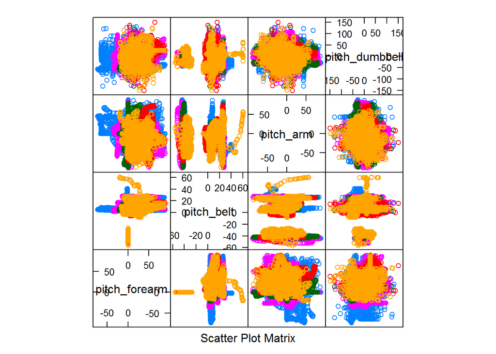

## BUILD 1st MODEL with train1 data

We select variables, use principal component analysis to reduce the number of variables and use gbm to do the prediction

## APPLY 1ST MODEL to test1 and have accuracy check

```r
preProc <- preProcess(train1[, selectV], method="pca", thresh=0.8)
trainPC <- predict(preProc, train1[, selectV])
trainPC1 <- cbind(clas, trainPC)

set.seed(325)

modFit <- train(clas ~ ., data=trainPC1, method="gbm", verbose=FALSE)

testPC <- predict(preProc, test1[, selectV])
p <- predict(modFit, testPC)

confusionMatrix(test1$classe, p)
```

```
## Confusion Matrix and Statistics
##
##           Reference
## Prediction   A   B   C   D   E
##          A 469  17  36  34   2
##          B  65 250  34  16  14
##          C  30  20 267  18   7
##          D  17  13  34 248  10
##          E  31  27  28  19 256
##
## Overall Statistics
##
##                Accuracy : 0.7594
##                  95% CI : (0.7399, 0.7782)
##     No Information Rate : 0.3119
##     P-Value [Acc > NIR] : < 2.2e-16
##
##                   Kappa : 0.6949
##  Mcnemar's Test P-Value : 1.233e-14
##
## Statistics by Class:
##
##                      Class: A Class: B Class: C Class: D Class: E
## Sensitivity            0.7663   0.7645   0.6692   0.7403   0.8858
## Specificity            0.9341   0.9211   0.9520   0.9545   0.9372
## Pos Pred Value         0.8405   0.6596   0.7807   0.7702   0.7091
## Neg Pred Value         0.8981   0.9514   0.9185   0.9470   0.9794
## Prevalence             0.3119   0.1667   0.2034   0.1707   0.1473
## Detection Rate         0.2390   0.1274   0.1361   0.1264   0.1305
## Detection Prevalence   0.2844   0.1932   0.1743   0.1641   0.1840
## Balanced Accuracy      0.8502   0.8428   0.8106   0.8474   0.9115
```

## BUILD 2nd MODEL with the same train1 data

We select variables, use scale and gbm to do the prediction

## APPLY 2nd MODEL to same test1 data and have accuracy check

```r
preProc_2 <- preProcess(train1[, selectV], method="scale")
trainPC <- predict(preProc_2, train1[, selectV])
trainPC1 <- cbind(clas, trainPC)
rm(trainPC)

set.seed(325)

modFit_2 <- train(clas ~ ., data=trainPC1, method="gbm", verbose=FALSE)

testPC <- predict(preProc_2, test1[, selectV])
p2 <- predict(modFit_2, testPC)

confusionMatrix(test1$classe, p2)
```

```
## Confusion Matrix and Statistics
##
##           Reference
## Prediction   A   B   C   D   E
##          A 537   9   5   5   2
##          B  33 325  17   2   2
##          C   3  13 320   4   2
##          D   1   6  20 294   1
##          E   1   6  13   4 337
##
## Overall Statistics
##
##                Accuracy : 0.9241
##                  95% CI : (0.9114, 0.9354)
##     No Information Rate : 0.2931
##     P-Value [Acc > NIR] : < 2.2e-16
##
##                   Kappa : 0.9039
##  Mcnemar's Test P-Value : 6.683e-06
##
## Statistics by Class:
##
##                      Class: A Class: B Class: C Class: D Class: E
## Sensitivity            0.9339   0.9053   0.8533   0.9515   0.9797
## Specificity            0.9849   0.9663   0.9861   0.9831   0.9852
## Pos Pred Value         0.9624   0.8575   0.9357   0.9130   0.9335
## Neg Pred Value         0.9729   0.9785   0.9660   0.9909   0.9956
## Prevalence             0.2931   0.1830   0.1911   0.1575   0.1753
## Detection Rate         0.2737   0.1656   0.1631   0.1498   0.1718
## Detection Prevalence   0.2844   0.1932   0.1743   0.1641   0.1840
## Balanced Accuracy      0.9594   0.9358   0.9197   0.9673   0.9824
```